# GoM cod and haddock RDM

Lou Carr-Harris

2024-06-11

This file is an exploratory analysis of the effect of climate-induced shifts in angler catch-per-trip of Gulf of Maine cod and haddock. Results are based on 100 iterations of the recreation demand model. The RDM is calibrated to 2020 fishery conditions.

### Decadal bottom temp trends

Mean monthly bottom temps by decade, red line indicates decadal average. Bars represent mean monthly temp +/- 1.96*standard dev.

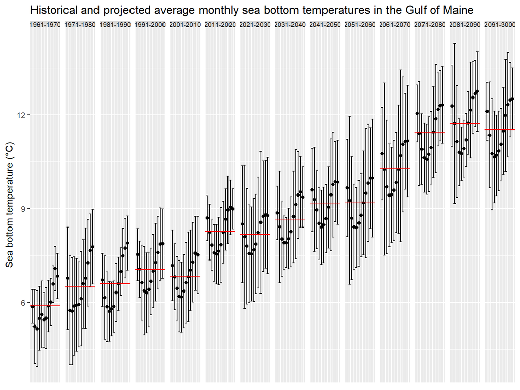

Projected differences in average monthly sea bottom temperatures relative to 2020. Bars represent lower and upper bounds of the projected average monthly temperatures. Red lines indicate differences between the decadal and 2020 annual average.

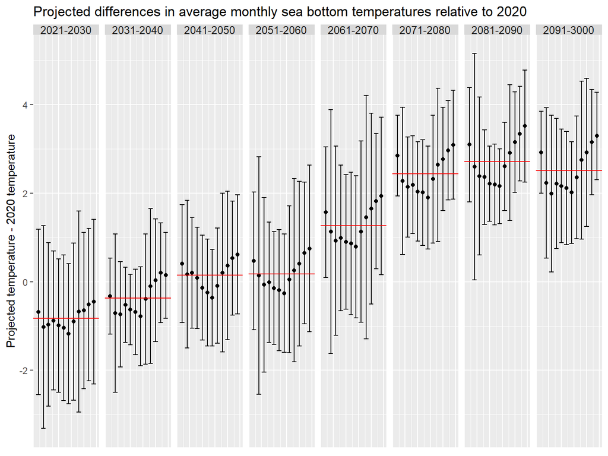

### Baseline (2020) fishery statistics

Index “_i” indicates per choice occasion variable

```
           variable     mean       sd
               draw     50.5  29.0115
    estimated_trips 312755.1   0.9653
 n_choice_occasions   483934 2193.714
      tot_cod_catch 588077.5 1903.489
       tot_keep_cod 5044.494  53.3831
        tot_rel_cod   583033 1897.925
     tot_hadd_catch  1918895  4220.46
      tot_keep_hadd  1004515 2038.446
       tot_rel_hadd 914379.9 2380.872
         cod_keep_i   0.0104    1e-04
        hadd_keep_i   2.0758   0.0091
      cod_keep_trip   0.0161    2e-04
     hadd_keep_trip   3.2118   0.0065
        cod_catch_i   1.2152   0.0067
       hadd_catch_i   3.9653    0.018
     cod_catch_trip   1.8803   0.0061
    hadd_catch_trip   6.1355   0.0135
```

### Baseline welfare calculations

After calibrating the simulation model to 2020 fishery conditions, I re-ran the model under two closure scenarios: (a) bag limits for both cod and haddock set to zero, and (b) bag limits for cod only set to zero.  
$~$

#### Scenario (a): close both fisheries

```
            variable     mean       sd
              cv_sum 30461985 157733.2
       tot_cod_catch 479327.9 2081.661
      tot_hadd_catch  1539889  5020.69
          cod_keep_i        0        0
         hadd_keep_i        0        0
       cod_keep_trip        0        0
      hadd_keep_trip        0        0
         cod_catch_i   0.9895   0.0065
        hadd_catch_i   3.1788    0.019
      cod_catch_trip   1.8434   0.0068
     hadd_catch_trip   5.9222   0.0132
             cv_trip 117.1531    0.681
 percent_redux_trips -16.8614   0.1755
```

#### Scenario (b): close cod only

```
            variable    mean       sd
              cv_sum  429052  85388.3
       tot_cod_catch  586237 1958.148
      tot_hadd_catch 1916058 4329.256
          cod_keep_i       0        0
         hadd_keep_i  2.0701   0.0097
       cod_keep_trip       0        0
      hadd_keep_trip  3.2133   0.0066
         cod_catch_i  1.2102   0.0063
        hadd_catch_i  3.9553   0.0186
      cod_catch_trip  1.8785   0.0061
     hadd_catch_trip  6.1396   0.0126
             cv_trip  1.3749    0.274
 percent_redux_trips -0.2152   0.0491
```

### Historical projected fishery outcomes

#### Total CV

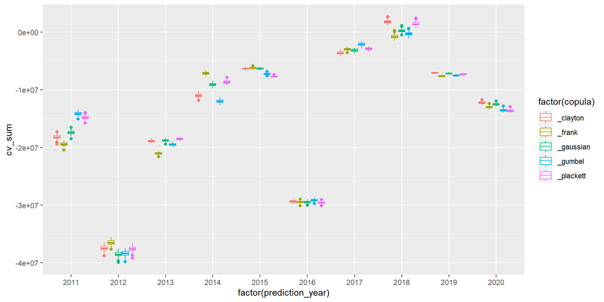

#### Difference in total CV between ind. and corr (tot_cv_corr-tot_cv_ind)

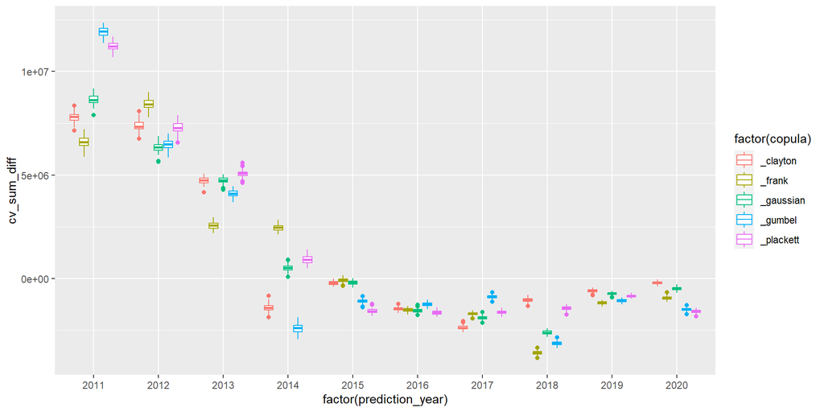

#### CV per trip

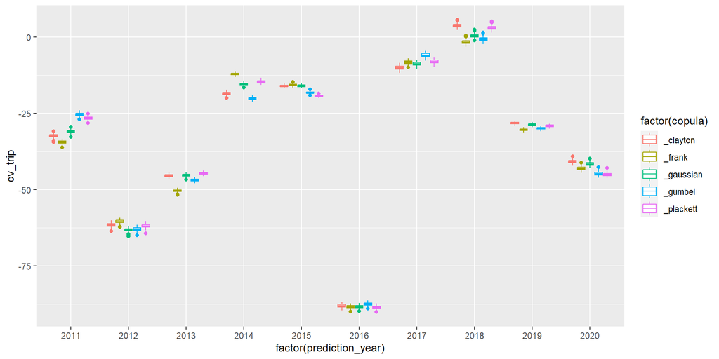

#### Difference in CV per trip between ind. and corr (trip_cv_corr-trip_cv_ind)

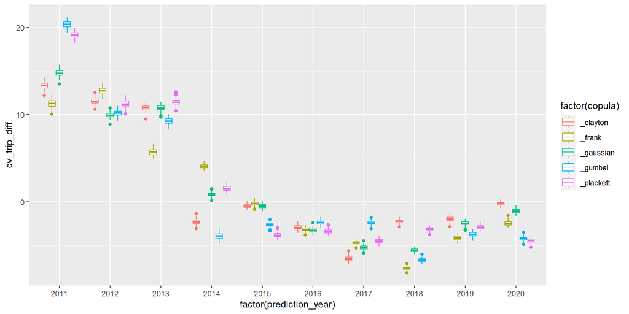

### Annual fishery outcomes under climate-induced changes in catch-per-trip

Each tab contains different projected fishery outcomes across copula models.

#### CV as a proportion of CV under full-closure of 2020 fishery

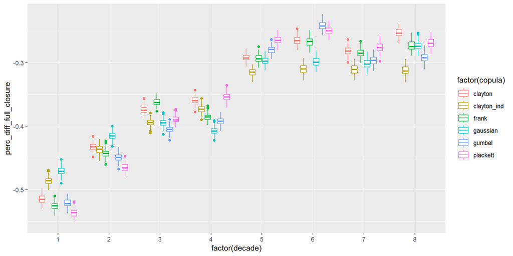

#### Total CV

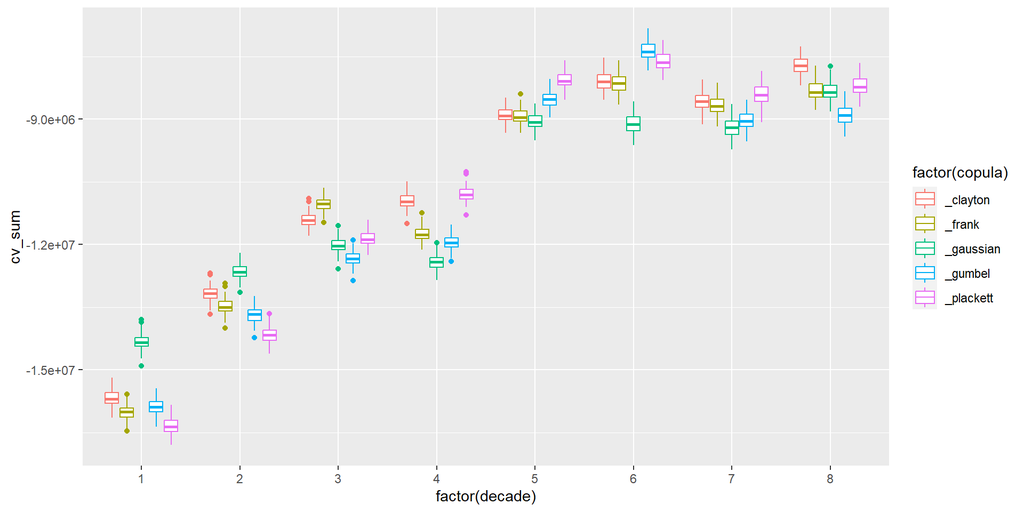

#### Difference in total CV between ind. and corr (tot_cv_corr-tot_cv_ind)

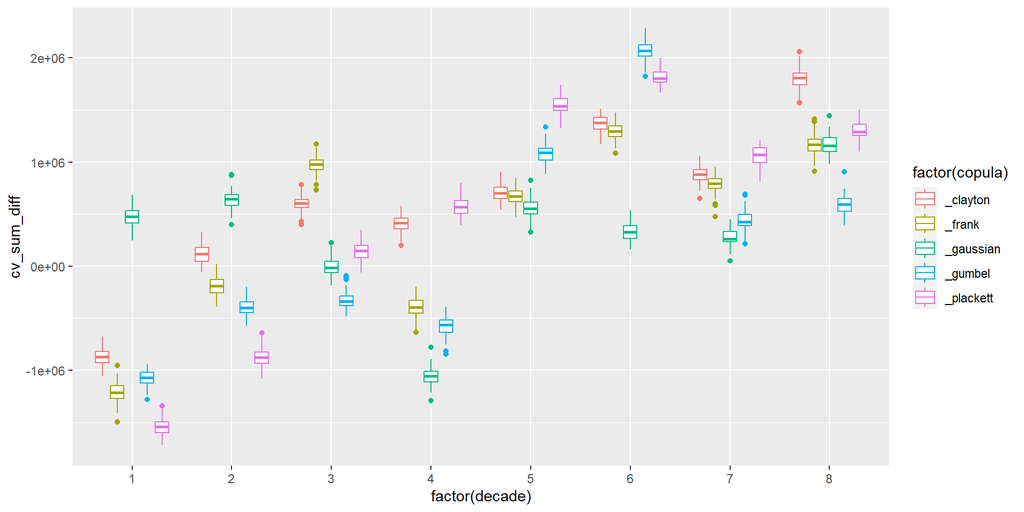

#### CV per trip

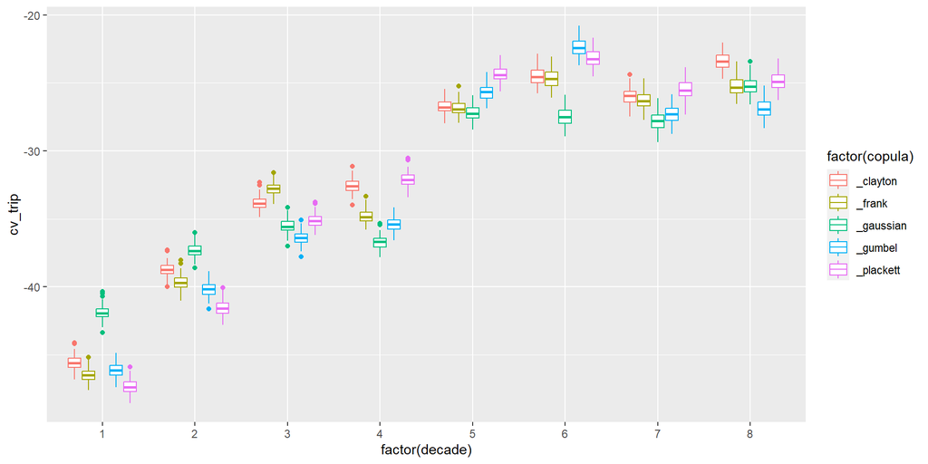

#### Difference in CV per trip between ind. and corr (cv_trip_corr-cv_trip_ind)

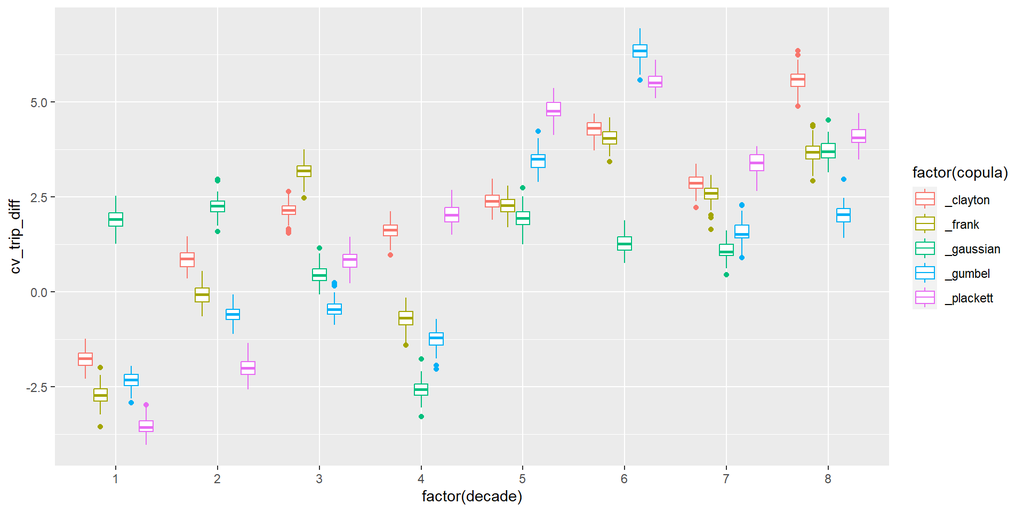

#### cod catch

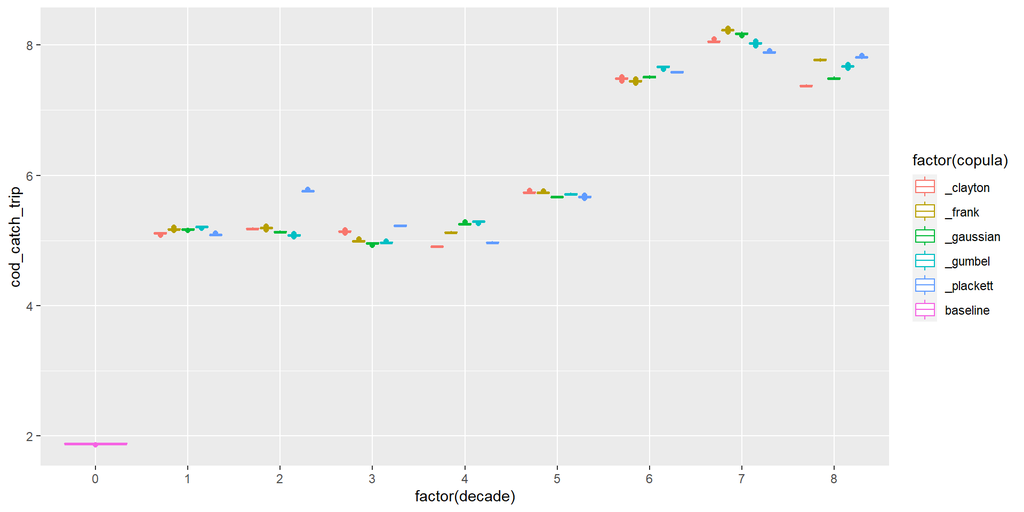

#### cod keep

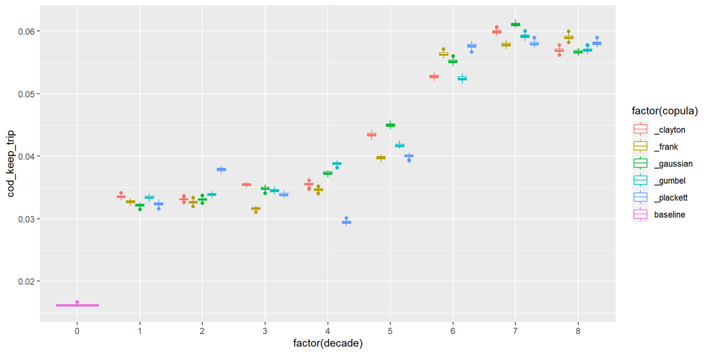

#### hadd catch

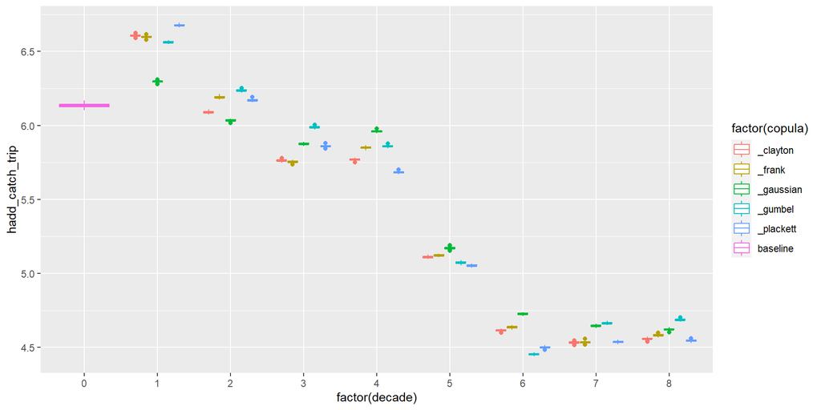

#### hadd keep

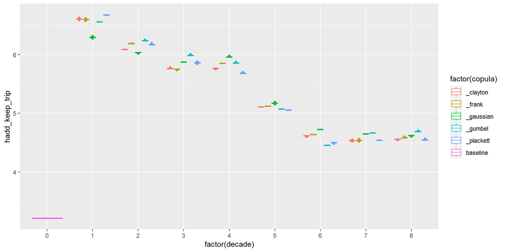

#### ktau keep

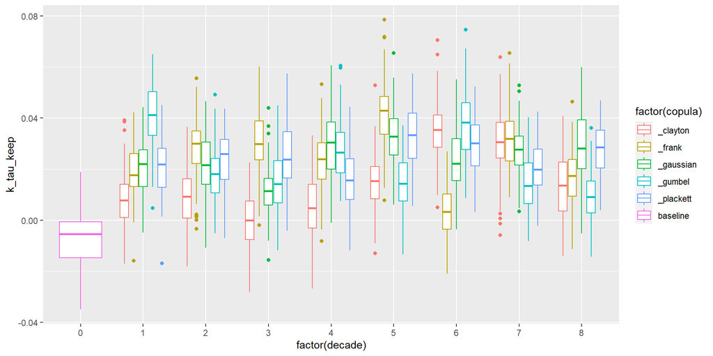

#### ktau catch

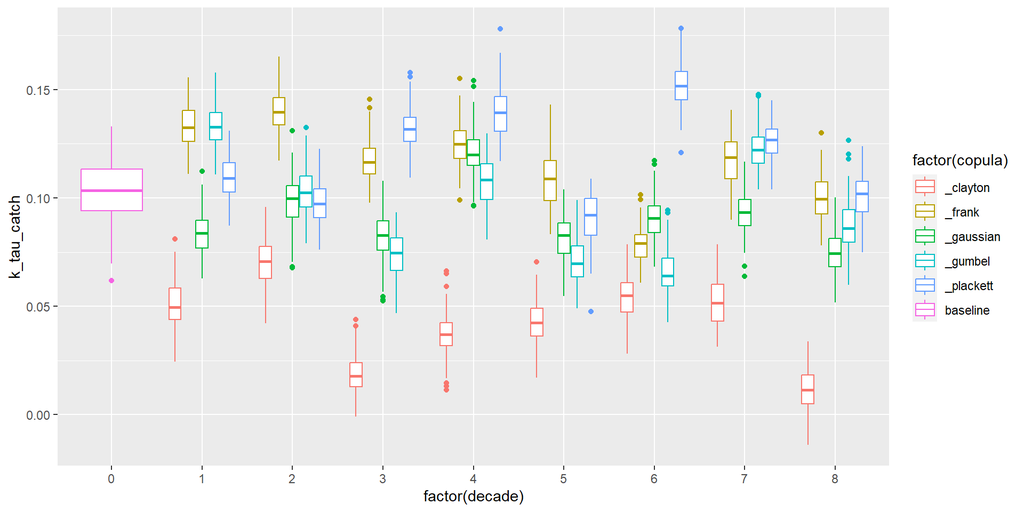

### OLS meta-analaysis of simulation results

The following OLS regression uses as data the 10 sets of results above (5 copulas, each with independent and correlated catch).

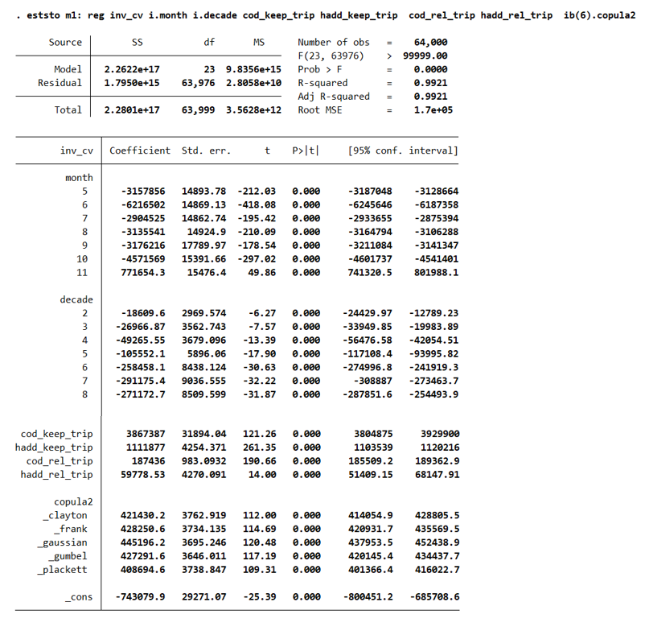

OLS results of total monthly CV

### Monthly fishery outcomes under climate-induced changes in catch-per-trip

Number of directed trips by month in 2020 (total=312,757):

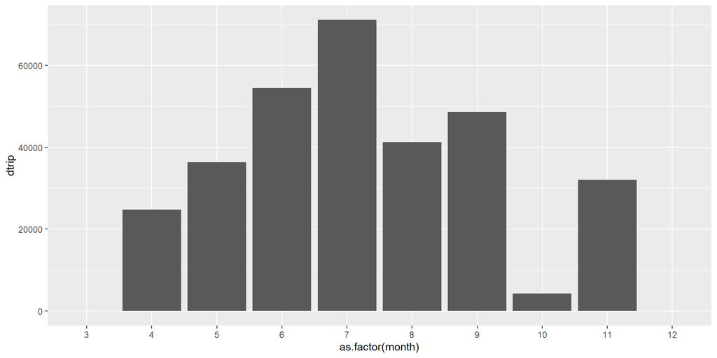

Each tab below contains projected fishery outcomes at the monthly level based on input data from alternative copula models.

#### Total CV

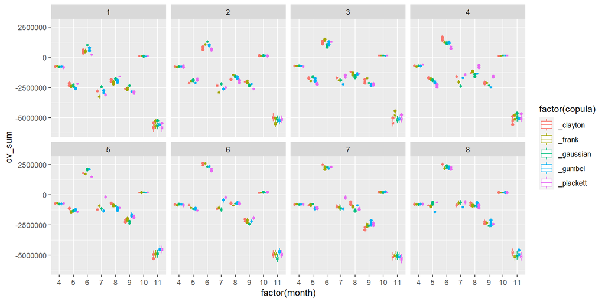

#### Difference in total CV between ind. and corr (tot_cv_corr-tot_cv_ind)

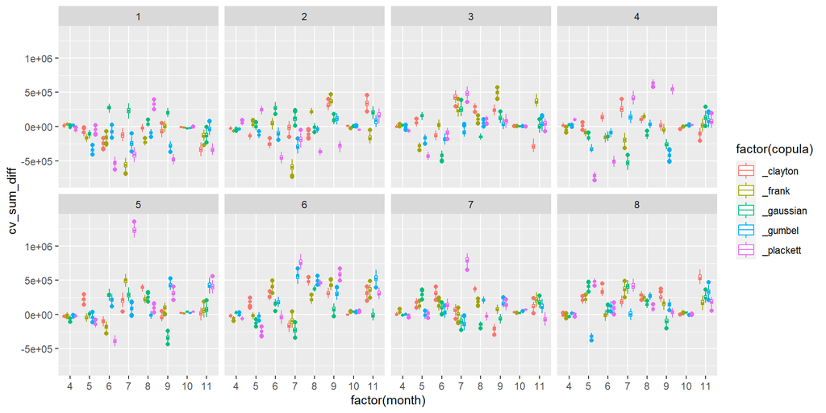

#### CV per trip

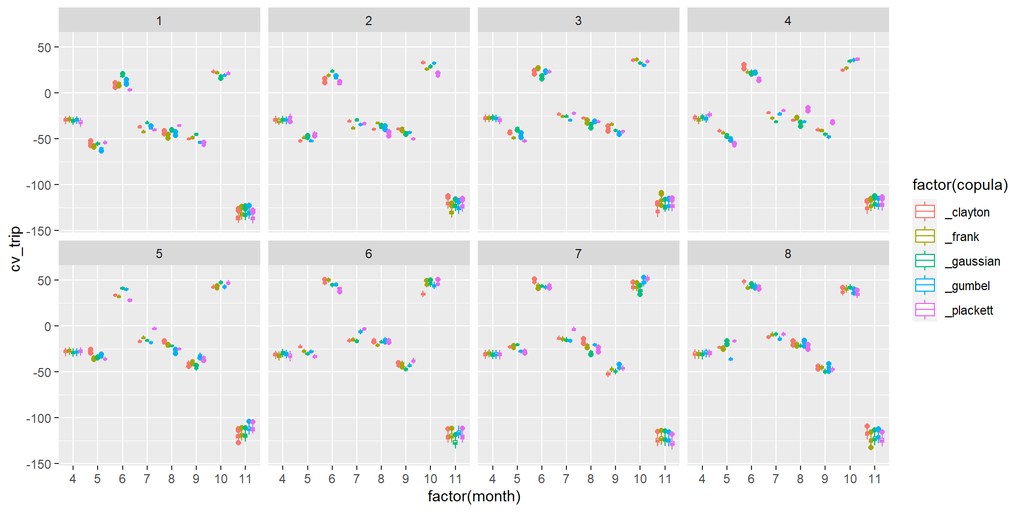

#### Difference in CV per trip between ind. and corr (cv_trip_corr-cv_trip_ind)

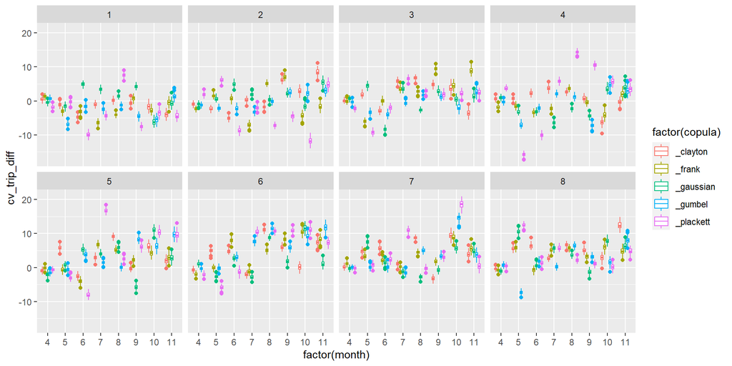

#### cod catch

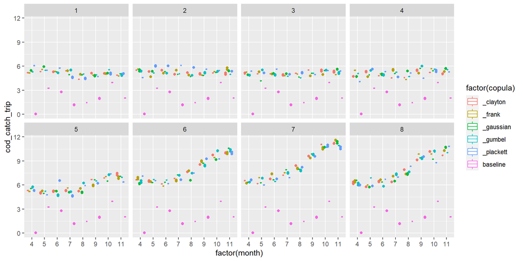

#### cod keep

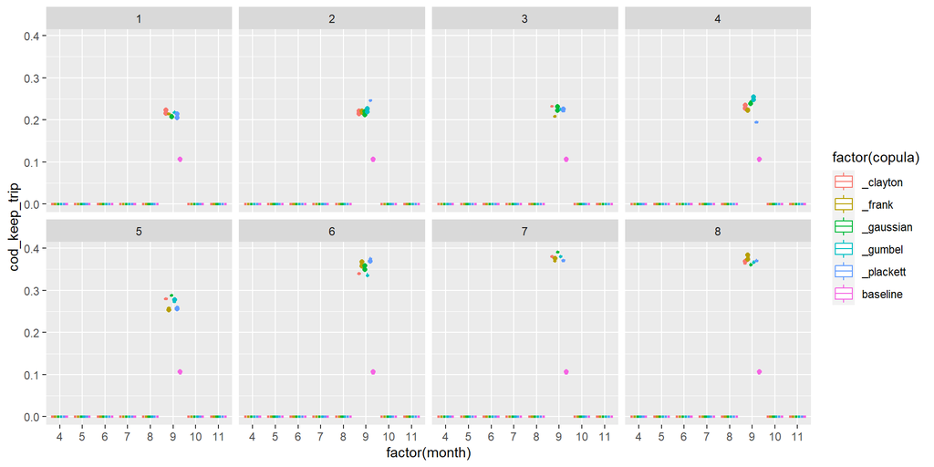

#### hadd catch

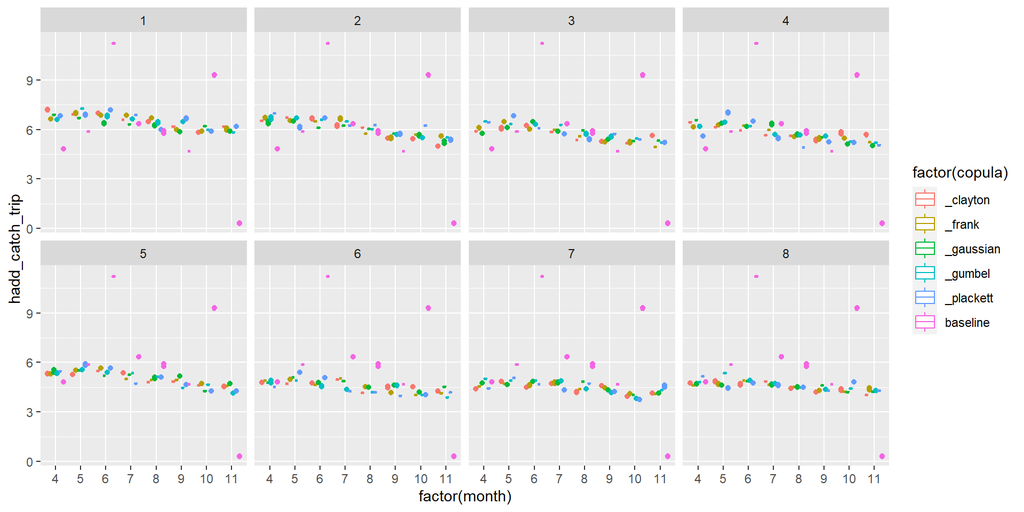

#### hadd keep

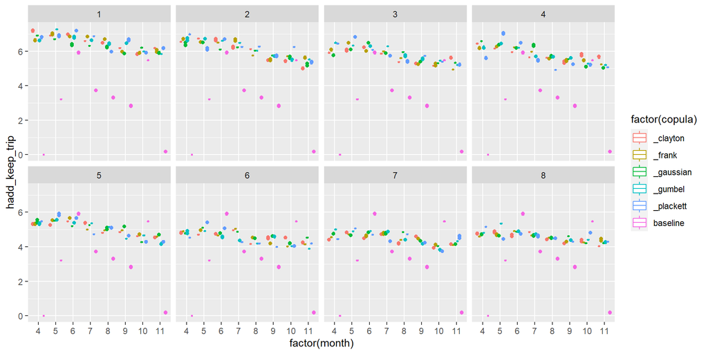

#### ktau keep

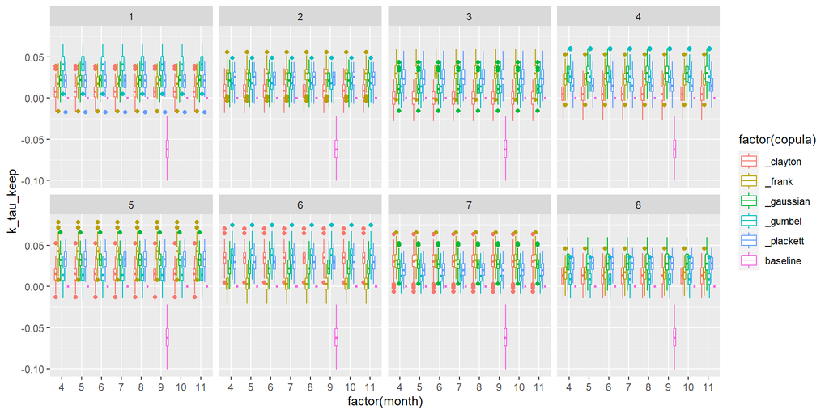

#### ktau catch

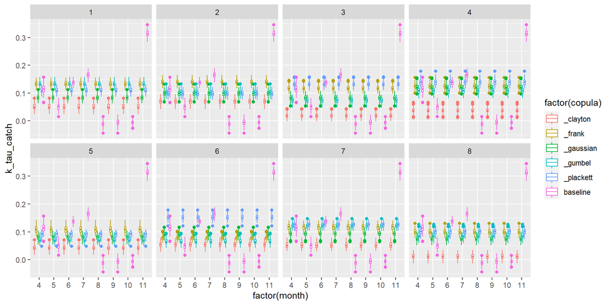